# Lab3_Lymar2

### Лабораторна робота №2. Аналіз складності алгоритмів (short version)

### Виконав студент групи КН-23-1 Лимар Дмитро

**Мета:** *Освоїти аналіз складності алгоритмів як технологію на прикладі алгоритмів сортування методами вставляння та бульбашки.*

## Що я буду вміти?

- Виконувати асимптотичний аналіз складності алгоритмів.
- Досліджувати часову складінсть алгоритмів емпіричним шляхом засобами мови `Python`.
- Вибирати оптимальний алгоритм.
- Генерувати випадкові послідовності чисел засобами `Python`
- Будувати графіки засобами бібліотеки `matplotlib`

## Оцінка часу роботи програми емпіричним шляхом на мові Python

Один з можливих підходів оцінки часу виконання програми, написаної на Python, може бути реалізований за допомогою пакету `time`.  
Нижче наведено код процедури на `Python`, який реалізує алгоритм сортування методом вставки, і дозволяє оцінити час її виконання.

```python
import time
#
start_time = time.time()
# Сорутвання методом вставок (включення)

def insertion_sort(nums):
    # починаємо з другого елемента
    for j in range(1, len(nums)):
        key = nums[j]
        # Зберігаємо посилання на індекс першого елемента
        i = j - 1
        # Елементи відсортованого сегрмента переміщуємо вперед, якщо вони більше елемента вставки
        while i >= 0 and nums[i] > key:
            nums[i + 1] = nums[i]
            i -= 1
        # Вставляємо елемент
        nums[i + 1] = key


# Перевірка
random_list_of_numbers = [0, -5, 120, 18, 21, 4]

insertion_sort(random_list_of_numbers)
print(random_list_of_numbers)

print("--- %s seconds ---" % (time.time() - start_time))
```

```
[-5, 0, 4, 18, 21, 120]
--- 0.0 seconds ---
```

Для того, щоби дослідити функцію часової залежності $T(n)$ від розміру задачі, необхідно вміти:

- генерувати послідовності чисел заданої довжини
- будувати графіки у середовищі Anaconda Python.

Генерація випадкових послідовностей заданої довжини заданого розподілу, в тому числі і цілочисельних, у середовищи `Python` може бути здійснена засобами стандартної бібліотеки `random`. (Див. детально [тут](https://www.youtube.com/watch?v=_uQrJ0TkZlc) тему `Generating Random Values`).

Покажемо один з можливих варіантів побудови графіка функції за допомогою бібліотеки `matplotlib`.

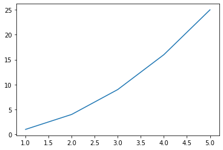

```python
import matplotlib.pyplot as plt
%matplotlib inline
plt.plot([1, 2, 3, 4, 5], [1, 4, 9, 16, 25])
```

Детально розібратися з установкою бібілотеки `matplotlib` можна [тут](https://devpractice.ru/matplotlib-lesson-1-quick-start-guide/).

## Завдання для самостіної роботи

1. Завантажити `Python Anaconda` та активувати в ньому віртуальне середовище, створене при виконанні попередньої лабораторної роботи.
2. Створити Notebook-документ `<lab_2_StudentLastName>` за допомогою Jupyter Notebook. (Див. [тут](https://devpractice.ru/python-lesson-1-install/), [тут](https://devpractice.ru/python-lesson-6-work-in-jupyter-notebook/) і [тут](https://jupyter-notebook.readthedocs.io/en/stable/notebook.html)).
3. Виконати теоретичні розрахунки асимптотичної складності алгоритмів сорутвання методами вставки та бульбашки.

**Відповідь:**

Сортування методом вставки має найгірший випадок буде $T(n) = 1 + 2 + 3 + \ldots + (n - 1) = \frac{(n - 1) n}{2} = O(n^2)$, в методі сортування бульбашкою найгірший випадок буде $T(n) = \sum_{i=1}^{n-1} i = \frac{n(n-1)}{2} = O(n^2)$, виходить що обидва алгоритми мають найгірший випадок $О(n^2)$

4. Реалізувати на Python алгоритм сортування методом бульбашки.

**Відповідь:**

```python
def bubble_sort(arr):
    n = len(arr)
    for i in range(n):
        swapped = False
        for j in range(0, n-i-1):
            if arr[j] > arr[j+1]:
                arr[j], arr[j+1] = arr[j+1], arr[j]
                swapped = True
        if not swapped:
            break
    return arr
```

5. Дослідити реальний час виконання обох алгоритмів на `Python` і побудувати графіки залежностей $T_{insert}(n)$ та $T_{buble}(n)$ для $n = [5, 10, 50, 100, 500, 1000, 2000, 3000, 4000, 5000, 10000, 20000, 50000, 100000]$, згенерувавши відповідні цілочисельні масиви.

**Відповідь:**

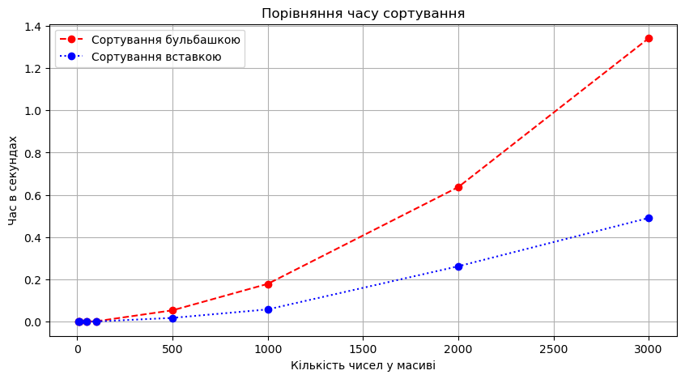

```python
import random
import time
import matplotlib.pyplot as plt

def generate_random_list(size, lower_bound, upper_bound):
    return [random.randint(lower_bound, upper_bound) for _ in range(size)]

def bubble_sort(arr):
    n = len(arr)
    for i in range(n):
        swapped = False
        for j in range(0, n-i-1):
            if arr[j] > arr[j+1]:
                arr[j], arr[j+1] = arr[j+1], arr[j]
                swapped = True
        if not swapped:
            break
    return arr

def insertion_sort(nums):
    for j in range(1, len(nums)):
        key = nums[j]
        i = j - 1
        while i >= 0 and nums[i] > key:
            nums[i + 1] = nums[i]
            i -= 1
        nums[i + 1] = key
    return nums

sizes = [5, 10, 50, 100, 500, 1000, 2000, 3000]
times_bubble = []
times_insertion = []

for size in sizes:
    random_list = generate_random_list(size, -3000, 3000)

    # Timing bubble sort
    start_time = time.time()
    bubble_sort(random_list.copy())
    end_time = time.time()
    times_bubble.append(end_time - start_time)

    # Timing insertion sort
    start_time = time.time()
    insertion_sort(random_list.copy())
    end_time = time.time()
    times_insertion.append(end_time - start_time)

# Plotting the results
plt.figure(figsize=(10, 5))

# Plot bubble sort results with red color and dashed line
plt.plot(sizes, times_bubble, label='Сортування бульбашкою', color='red', linestyle='dashed', marker='o')

# Plot insertion sort results with blue color and dotted line
plt.plot(sizes, times_insertion, label='Сортування вставкою', color='blue', linestyle='dotted', marker='o')

plt.xlabel('Кількість чисел у масиві')
plt.ylabel('Час в секундах')
plt.title('Порівняння часу сортування')
plt.legend()
plt.grid(True)
plt.show()
```

6. Робочий документ оформити у вигляді Notebook-документу (файл **.ipynb**).
7. Дати відповіді на контрольні запитання.
8. Скомпілювати звіт у форматі **.html**. Для цього необхідно завантажити термінал і у командному рядку запустити наступну команду:

`jupyter nbconvert lab_2_StudentLastName.ipynb --to html`

9. Представити звіт у вигляді архіву. Проект має складатися мінімум з двох файлів: `lab_2_StudentLastName.ipynb` та `lab_2_StudentLastName.html`

## Контрольні запитання

1. Що таке $O-нотація$ і чим вона відрізняється від $\Omega-нотації$?

**Відповідь:**

$O-нотація$ - описує верхню межу часової складності алгоритму в найгіршому випадку.

$\Omega-нотація$ - використовується для оцінки асимптотичної нижньої межі складності алгоритму.

$O-нотація$ та $\Omega-нотація$ використовуються для того, щоб дати повну картину про те, як швидко чи повільно може працювати алгоритм у всіх можливих сценаріях від високого до низького навантаження.

2. Яку часову складність має алгоритм сортування методом вставки за найсприятливішої умови, коли масив відсортовано? Відповідь обгрунтувати.

**Відповідь:**

Часова складність алгоритму сортування методом вставки у найкращому випадку є $O(n)$.

На кожну ітерацію алгоритм витрачає лише стільки часу, скільки потрібно для одного порівняння та можливо одного зсуву. Оскільки масив вже відсортований, таких операцій буде $O(n)$

3. Дати визначення ефективного алогоритму.

**Відповідь:**

Ефективний алгоритм - це алгоритм, який виконує своє завдання швидко та ефективно відносно обсягу вхідних даних.

4. Пояснити поняття головного параметра (розміру) задачі.

**Відповідь:**

Головний параметр(розмір) задачі- це величина, яка характеризує обсяг вхідних даних для нашої задачі. Тобто є ключовою характеристикою для оцінки ефективності алгоритмів, від якої залежить як швидко і скільки ресурсів потрібно для вирішення задачі даним алгоритмом

5. Функція часової складності має вигляд: $F(N)=N^3+7N^2-14N$

Як записати асимптотичну складність в нотації O()?

**Відповідь:**

Запис асимптотичної складності цієї функції буде таким: $F(N) = O(N^3)$

### References

1. Anaconda (Python distribution). https://uk.wikipedia.org/wiki/Anaconda_(Python_distribution)
2. Conda. https://conda.io/en/latest/
3. [Научно-издательская система Quarto](https://data-visualization-blog.netlify.app/posts/quarto/)
4. [Callout Blocks. Markdown Syntax](https://quarto.org/docs/authoring/callouts.html)